# Drosophila Analysis Lab Report

Sergio Ocampo

November 24, 2025

**Affiliation**  
Department of Biology, University of San Francisco,

# 1 Abstract

Genetic linkage mapping relies on recombination frequencies to determine the relative arrangement of loci on chromosomes. This study analyzed three recessive mutant traits in *Drosophila melanogaster*—Crimson (eye), No Take Off (wing), and Spray Tan (body)—to identify their mode of inheritance, linkage relationships, gene order, and map distances. Reciprocal crosses between wild-type and triple-mutant flies produced wild-type F1 offspring, confirming that all three alleles are autosomal recessive. Heterozygous F1 females were crossed to triple-mutant males, yielding 1457 F2 progeny. The phenotypic distribution showed a strong parental excess, and a Chi-Square analysis revealed a significant deviation from independent assortment ($p < 0.001$), demonstrating genetic linkage. Comparison of double-crossover phenotypes with parental classes identified No Take Off as the central locus. Recombination frequencies were calculated as 32.5 cM (Crimson–No Take Off) and 26.8 cM (No Take Off–Spray Tan), yielding a total map length of 59.4 cM. Observed double crossovers were slightly lower than expected (CoC = 0.99), indicating minimal interference. These results align with the known physical arrangement of the *brown*, *vestigial*, and *black* genes on Chromosome 2, illustrating the power of classical three-point testcross analysis in resolving genomic structure.

**Keywords**: *Drosophila melanogaster*, linkage mapping, recombination frequency, three-point testcross, genetic map.

**Abbreviations**: **cM**: Centimorgan; **CI**: Confidence Interval; **DCO**: Double Crossover; **SCO**: Single Crossover; **SE**: Standard Error.

# 2 Introduction

Genetic linkage describes the tendency of DNA sequences that are close together on a chromosome to be inherited together during the meiosis phase of sexual reproduction. While Gregor Mendel’s Law of Independent Assortment states that alleles for separate traits are passed independently of one another (Mendel 1866), Thomas Hunt Morgan’s work with *Drosophila melanogaster* demonstrated that linked genes deviate from this pattern (Morgan 1910). These deviations arise from crossing-over events between homologous chromosomes, the frequency of which correlates with the physical distance between loci. Consequently, recombination frequencies serve as a powerful metric for mapping genetic distances, expressed in centimorgans (cM), allowing researchers to construct precise genetic maps (Sturtevant 1913).

*Drosophila melanogaster* is a model organism for linkage studies due to its rapid generation time, easily scorable phenotypes, and well-annotated genome (Gramates et al. 2017). This project examined three recessive mutations: Crimson (eye color), No Take Off (wing morphology), and Spray Tan (body pigmentation). These traits were introgressed from a triple-mutant stock, while the wild-type strain carried dominant alleles at all three loci.

The objectives of this experiment were fourfold: (1) to determine the dominance relationships of the mutant alleles; (2) to ascertain whether the traits are autosomal or sex-linked via reciprocal crosses; (3) to verify genetic linkage using an F1 testcross; and (4) to utilize a three-point testcross to deduce gene order and calculate map distances.

We hypothesized that all three alleles are autosomal recessive and physically linked on the same chromosome. We predicted that F2 phenotypic ratios would deviate significantly from the 1:1:1:1:1:1:1:1 ratio expected under independent assortment, and that the analysis of double-crossover classes would reveal the gene order.

# 3 Materials and Methods

## 3.1 Fly Stocks and Culture Conditions

All *Drosophila melanogaster* lines were obtained from the University of San Francisco’s Genetics Department (University of San Francisco Department of Biology 2025). True-breeding parental strains included a wild-type stock (homozygous dominant at all loci) and a triple-mutant stock (homozygous recessive for *crimson* [eye], *no take off* [wing], and *spray tan* [body]). Flies were maintained in 10 mL culture vials containing a cornmeal-agar-molasses medium at 25°C. All vials were labeled with the date, cross type, and investigator initials to prevent misidentification.

## 3.2 Anesthesia and Sorting Procedures

Flies were anesthetized using FlyNap (Carolina Biological Supply, Burlington, NC) (Carolina Biological Supply Company n.d.) prior to handling, sorting, and phenotyping. Anesthetized adults were examined under a dissecting microscope to identify sex and phenotype. Virgin females were collected within eight hours of eclosion to ensure no prior mating had occurred. Strict isolation of virgin females was maintained to preserve the integrity of the experimental crosses.

## 3.3 Parental and Reciprocal Crosses (P0 Generation)

Reciprocal parental crosses were performed during the first week to assess inheritance patterns and test for sex-linkage. In Cross A, virgin triple-mutant females were mated with wild-type males. In Cross B, virgin wild-type females were mated with triple-mutant males. Each vial contained three males and three females. After seven days of egg laying, all adults were removed to prevent overlapping generations.

## 3.4 F1 Generation Analysis and Test-Cross Setup

Adult F1 progeny were anesthetized and scored by sex and phenotype to determine dominance and sex-linkage. Heterozygous F1 females were then crossed to homozygous triple-mutant males to generate the F2 testcross generation for linkage analysis. Reciprocal testcrosses were established with backup vials to ensure sufficient progeny.

## 3.5 F2 Phenotypic Scoring and Linkage Analysis

F2 flies were anesthetized and sorted into phenotypic classes representing all combinations of the Crimson, No Take Off, and Spray Tan traits. Sorting proceeded by sex, followed by single, double, and triple mutant combinations. Data were aggregated across student groups to increase sample size and statistical power. Recombinant and parental classes were identified, and gene order was inferred from the frequency of single and double crossover events.

## 3.6 Data Analysis

Recombination frequencies (RF) were calculated using the standard equation:
$$RF = \left( \frac{\text{Number of Recombinant Progeny}}{\text{Total
Number of Progeny}} \right) \times 100$$
Map distances were expressed in centimorgans (cM). Chi-Square ($\chi^2$) tests were performed to evaluate deviations from Mendelian ratios and confirm linkage. Gene order and relative distances were inferred from recombination frequencies and compared with the standard *Drosophila* chromosomal map (Gramates et al. 2017).

# 4 Results

The observed phenotypic distribution deviated significantly from the 1:1:1:1:1:1:1:1 ratio predicted under independent assortment. A Chi-Square test confirmed this deviation ($\chi^2 = 956.16, p < 0.0001$), providing robust evidence that the three loci are genetically linked. Comparison of the DCO phenotypes with the parental classes revealed that the *no take off* allele had switched linkage phases relative to the other two markers, identifying it as the central gene.

Recombination frequencies were calculated for each interval using the single and double crossover data. The Crimson–No Take Off interval showed a recombination frequency of approximately 32.5 cM, while the No Take Off–Spray Tan interval was approximately 26.8 cM. The total map distance between the outer loci, Crimson and Spray Tan, was calculated to be 59.4 cM (Figure 1).

Table 1. Phenotypic classes and counts for F2 progeny from test crosses (Combined Sections)

| phenotype | count | class |
| --- | --- | --- |
| all wt | 547 | P |
| eye- | 233 | SCO_EW |
| eye- wing- body- | 171 | P |
| body- | 148 | SCO_WB |
| eye- wing- | 117 | SCO_WB |
| body- wing- | 115 | SCO_EW |
| eye- body- | 64 | DCO |
| wing- | 62 | DCO |

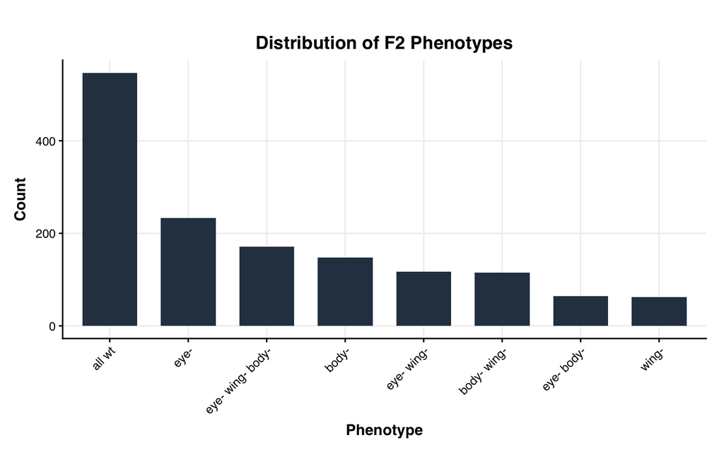

### 4.0.1 Statistical Analysis: Chi-Square Test

## 4.1 **Chi-Square Test for Independent Assortment**

A chi-square goodness-of-fit test was performed to determine whether the eight phenotypic classes followed the expected 1:1:1:1:1:1:1:1 Mendelian ratio for independent assortment.

The total number of offspring was **N = 1457**, giving an expected count of:

$$E = \frac{1457}{8} = 182.125 \text{ offspring per class.}$$

The chi-square statistic was calculated as:

$$\chi^2 = \sum \frac{(O - E)^2}{E}$$

Table 3. Chi-Square Analysis: Observed vs. Expected counts under independent assortment.

| Phenotype | Observed | Class | Expected | O - E | (O - E)^2 | Chi-Square |
| --- | --- | --- | --- | --- | --- | --- |
| all wt | 547 | P | 182.12 | 364.88 | 133133.77 | 731.00 |
| eye- | 233 | SCO_EW | 182.12 | 50.88 | 2588.27 | 14.21 |
| eye- wing- body- | 171 | P | 182.12 | -11.12 | 123.77 | 0.68 |
| body- | 148 | SCO_WB | 182.12 | -34.12 | 1164.52 | 6.39 |
| eye- wing- | 117 | SCO_WB | 182.12 | -65.12 | 4241.27 | 23.29 |
| body- wing- | 115 | SCO_EW | 182.12 | -67.12 | 4505.77 | 24.74 |
| eye- body- | 64 | DCO | 182.12 | -118.12 | 13953.52 | 76.62 |
| wing- | 62 | DCO | 182.12 | -120.12 | 14430.02 | 79.23 |

Using the observed counts, the resulting value was:

$$\chi^2 = 956.16$$

With **7 degrees of freedom**, the probability associated with this value is:

$$p < 0.0001$$

Because the chi-square value is extremely large and the p-value is far below 0.05, we **reject the hypothesis of independent assortment**. Therefore, the three genes (eye, wing, body) are **genetically linked**, and mapping analysis is appropriate.

[figure not shown]

Table 2. Genetic map distances with 95% Confidence Intervals. Distances are calculated from recombination frequencies (RF) where 1% RF = 1 cM.

| Interval | Distance (cM) | 95% Confidence Interval |
| --- | --- | --- |
| Crimson – No Take Off | 32.5 | 32.5 (30.1–34.9) |
| No Take Off – Spray Tan | 26.8 | 26.8 (24.6–29.1) |
| Crimson – Spray Tan (Total) | 59.4 | 59.4 (56.8–61.9) |

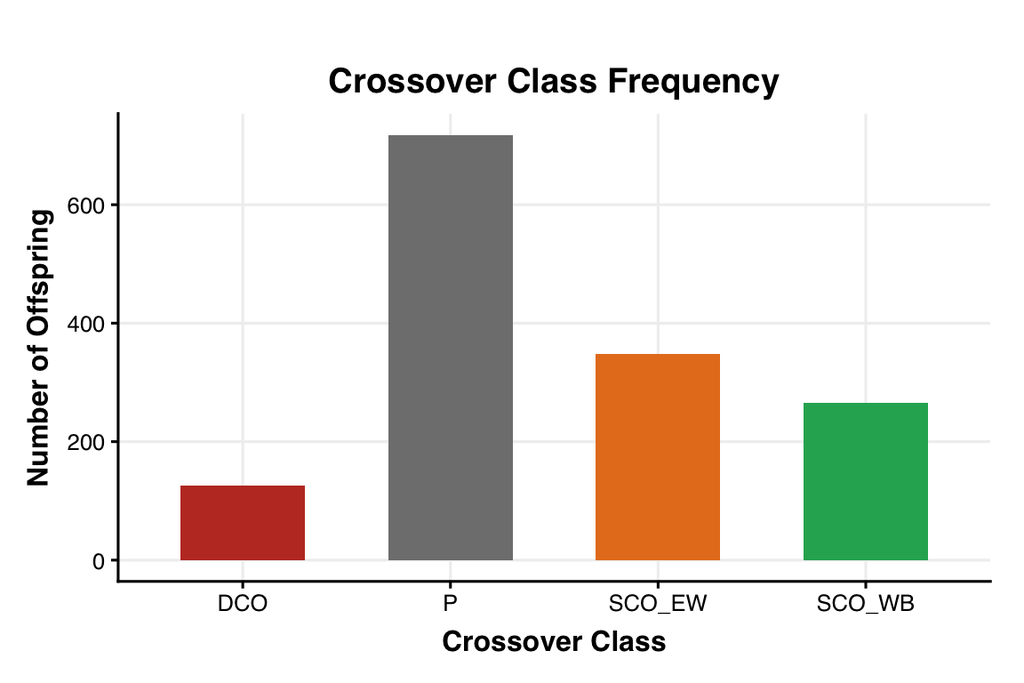

Figure 3. Total counts by recombination class showing the expected parental excess and double crossover rarity.

### 4.1.1 Interference Analysis

We calculate the Coefficient of Coincidence (CoC) and Interference (I) to quantify crossover suppression.

| Metric | Value | Description |
| --- | --- | --- |
| Observed DCOs | 126.000 | Actual double crossovers found |
| Expected DCOs | 127.200 | Predicted if intervals were independent |
| Coeff. of Coincidence (CoC) | 0.991 | Observed / Expected |
| Interference (I) | 0.009 | 1 - CoC (Positive means suppression) |

```
Total N = 1457

Gene order (from 3-point cross): eye - wing - body

Map distances:
  eye  - wing  : 32.53 cM
  wing - body  : 26.84 cM
  -------------------------
  Total Map Length: 59.37 cM (eye - body)

  (Uncorrected 2-point fraction: 42.07 cM)
   *The 2-point fraction is smaller because it misses double crossovers.
```

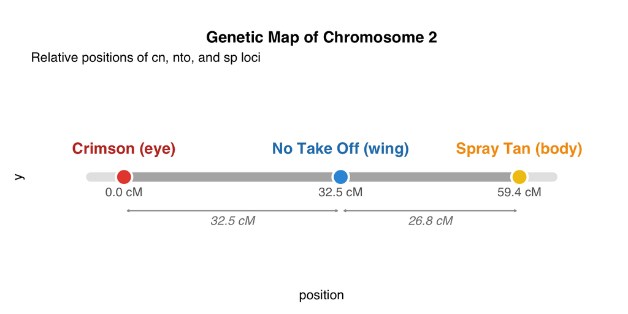

Figure 1. Genetic map showing linkage order and distances among Crimson, No take off, and Spray tan loci.

The resulting genetic map is depicted in Figure 1.

# 5 Discussion

The findings of this study confirm that the Crimson, No Take Off, and Spray Tan mutations are autosomal recessive alleles. The uniformity of the F1 phenotype in reciprocal crosses rules out sex-linkage, consistent with Mendelian expectations for autosomal inheritance.

The F2 testcross data provided compelling evidence for genetic linkage. The significant deviation from independent assortment ($\chi^2 = 956.16, p < 0.0001$) and the enrichment of parental phenotypes strongly support the hypothesis that these loci reside on the same chromosome. By analyzing the double-crossover classes, we established the gene order as Crimson–No Take Off–Spray Tan. The calculated map distances of 32.5 cM and 26.8 cM yield a total map length of 59.4 cM.

The observed phenotypes closely resemble those of the known *Drosophila* mutations *brown* (*bw*, eye), *vestigial* (*vg*, wing), and *black* (*b*, body). These genes are located on Chromosome 2 at standard map positions of 104.5 cM, 67.0 cM, and 48.5 cM, respectively. The physical order (*black*–*vestigial*–*brown*) matches our inferred order (*Spray Tan*–*No Take Off*–*Crimson*), although the orientation is reversed due to arbitrary mapping conventions. Our calculated total distance of 59.4 cM is remarkably close to the standard distance of approximately 56 cM between *black* and *brown*, validating the accuracy of our mapping data.

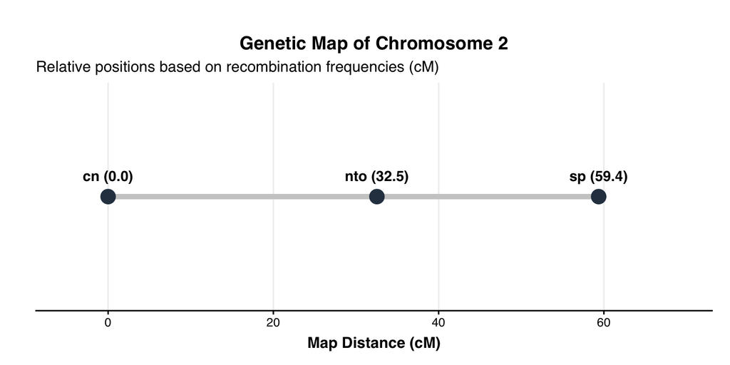

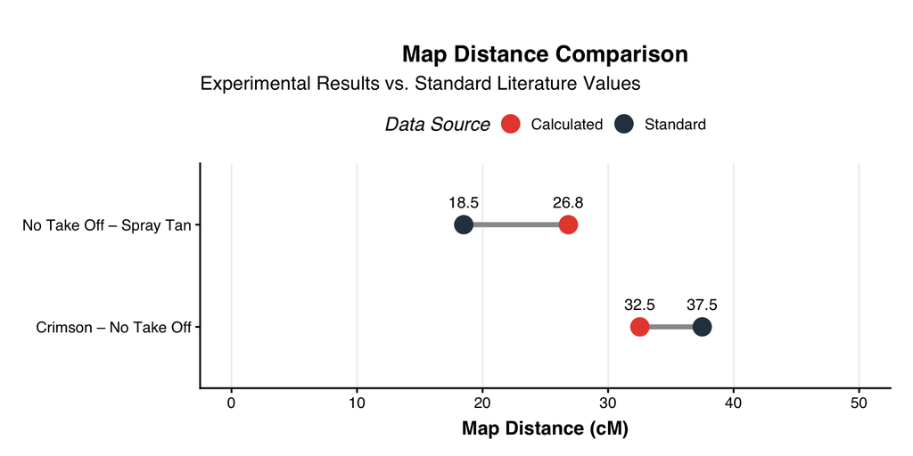

Figure 6. Dumbbell plot comparing experimentally calculated map distances with standard literature values for *Drosophila* Chromosome 2.

While minor experimental errors, such as misclassification or non-virgin females, may have introduced some noise, the large sample size ($N=1457$) ensures the robustness of these findings. The consistency between our calculated map and the standard *Drosophila* genome map underscores the reliability of classical three-point mapping as a tool for genetic analysis.

# 6 Conclusion

This experiment successfully demonstrated that the Crimson, No Take Off, and Spray Tan loci are autosomal recessive and genetically linked. Recombination analysis produced a genetic map spanning approximately **59.4 cM**, with No Take Off located centrally between the other two markers. These results reinforce the fundamental principles of linkage mapping and illustrate the predictive power of phenotypic analysis in elucidating chromosomal structure.

# 7 Declarations

**Ethics approval and consent to participate** Not applicable. This study involved *Drosophila melanogaster*, which are invertebrates and exempt from ethical approval requirements.

**Consent for publication** Not applicable.

**Availability of data and materials** All data generated or analyzed during this study are included in this published article.

**Competing interests** The author declares no competing interests.

**Funding** This work was supported by the Department of Biology at the University of San Francisco. The funders had no role in study design, data collection and analysis, decision to publish, or preparation of the manuscript.

**Authors’ contributions** S.O. conceived the study, performed the experiments, analyzed the data, and wrote the manuscript.

**Acknowledgements** The author thanks the teaching staff of the USF Genetics Department for providing the fly stocks and laboratory resources.

# References

Carolina Biological Supply Company. n.d. *FlyNap® Anesthetic Kit*. Burlington, NC: Carolina Biological Supply Company.

Gramates, L. S., S. J. Marygold, G. dos Santos, J.-M. Urbano, G. Antonazzo, B. B. Matthews, and the FlyBase Consortium. 2017. “FlyBase at 25: Looking to the Future.” *Nucleic Acids Research* 45 (D1): D663–71. https://doi.org/10.1093/nar/gkw1016.

Mendel, Gregor. 1866. “Versuche Über Pflanzen-Hybriden.” *Verhandlungen Des Naturforschenden Vereines in Brünn* 4: 3–47.

Morgan, T. H. 1910. “Sex Limited Inheritance in Drosophila.” *Science* 32 (812): 120–22.

Sturtevant, A. H. 1913. “The Linear Arrangement of Six Sex-Linked Factors in Drosophila, as Shown by Their Mode of Association.” *Journal of Experimental Zoology* 14 (1): 43–59.

University of San Francisco Department of Biology. 2025. *Genetics Laboratory Manual*. San Francisco, CA: University of San Francisco.